# HW10_Jie He

# Section 9.7

# Q3

# a

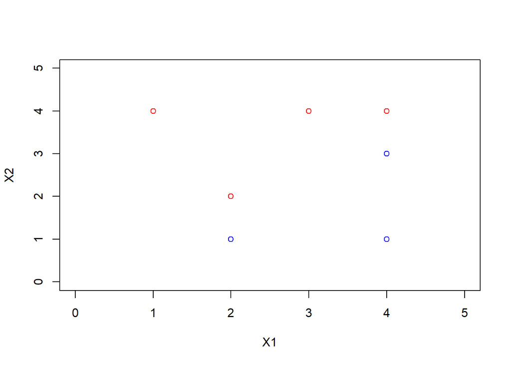

```r
X1 = c(3, 2, 4, 1, 2, 4, 4)
X2 = c(4, 2, 4, 4, 1, 3, 1)
color = c("red", "red", "red", "red", "blue", "blue", "blue")
plot(X1, X2, col = color, xlim = c(0, 5), ylim = c(0, 5))
```

# b

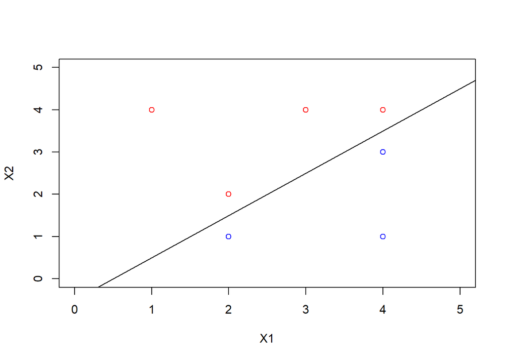

```r
plot(X1, X2, col = color, xlim = c(0, 5), ylim = c(0, 5))
abline(-0.5, 1)
```

From the graph, we can see that the optimal separating hyperplane should be between the points (4,3) & (4,4) and also between the points (2,1) & (2,2). Then it’s a line with (4,3.5) & (2,1.5) on it. Its equation can be expressed as
$$X1-X2-0.5=0$$

# c

The rule is: Classify to Red if
$$X1-X2-0.5<0$$
, and classify to Blue otherwise.

# d

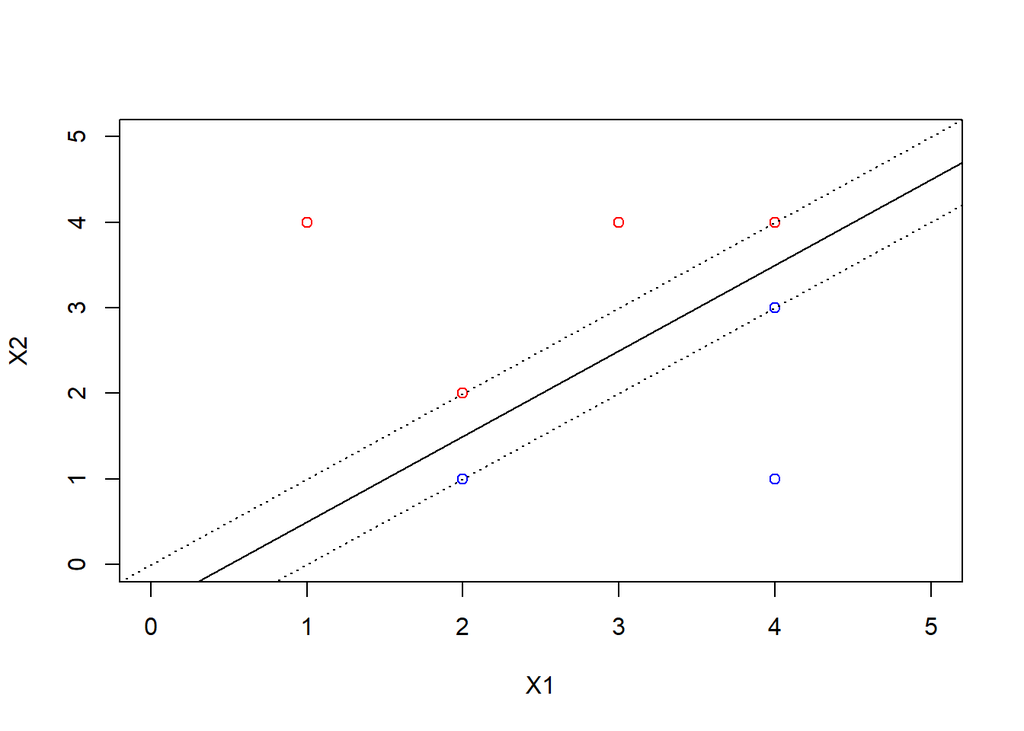

```r
plot(X1, X2, col = color, xlim = c(0, 5), ylim = c(0, 5))
abline(-0.5, 1)
abline(-1, 1, lty = 3)
abline(0, 1, lty = 3)
```

# e

The support vectors are (2,1), (2,2), (4,3), (4,4).

# f

From the graph, we can see that the maximal margin hyperplane would not be changed even if we moved the seventh observation because it is not a support vector.

# g

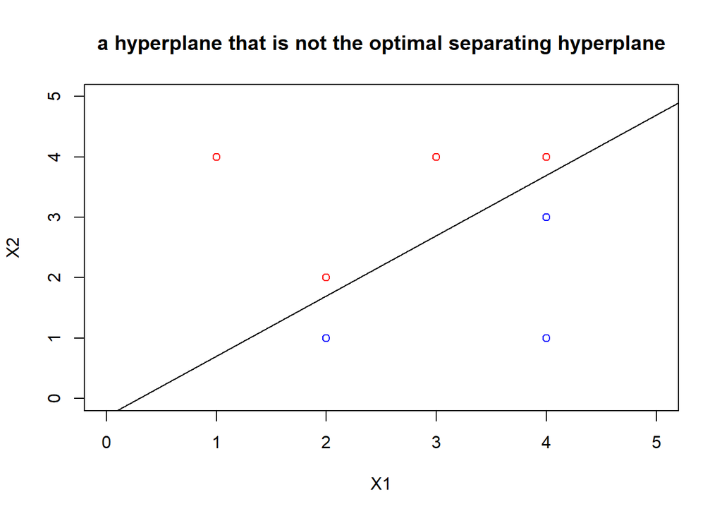

```r
plot(X1, X2, col = color, main = "a hyperplane that is not the optimal separating hyperplane", xlim = c(0, 5), ylim = c(0, 5))
abline(-0.3, 1)
```

The equation for this hyperplane is:
$$X1-X2-0.3=0$$

# h

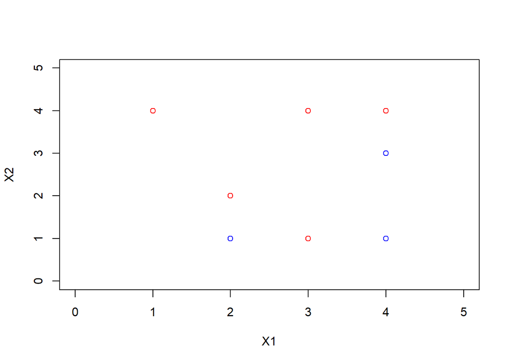

```r
plot(X1, X2, col = color, xlim = c(0, 5), ylim = c(0, 5))
points(c(3), c(1), col = c("red"))
```

The addition of the red one (3,1) makes that the two classes are no longer separable by a hyperplane.

# Q4

Generate the data according to the requirements first.

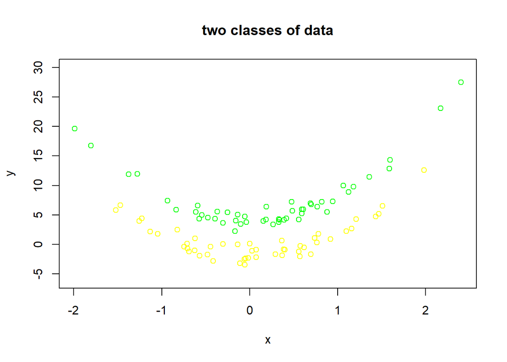

```r
require(e1071)
set.seed(1)
x <- rnorm(100)
y <- 4 * x^2 + 1 + rnorm(100)
class <- sample(100, 50)
y[class] <- y[class] + 3
y[-class] <- y[-class] - 3
plot(x[class], y[class], col = "green", main = "two classes of data", xlab = "x", ylab = "y", ylim = c(-6, 30))
points(x[-class], y[-class], col = "yellow")
```

support vector classifier

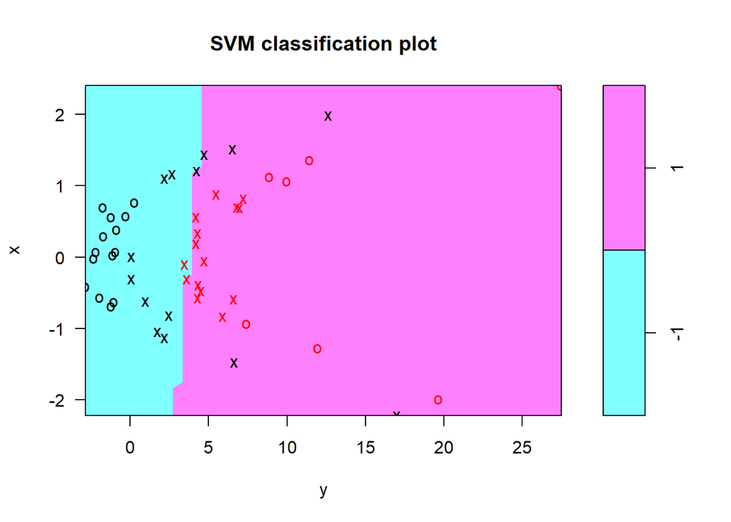

```r
z <- rep(-1, 100)
z[class] <- 1
mydata <- data.frame(x = x, y = y, z = as.factor(z))
training <- sample(100, 50)
train <- mydata[training, ]
test <- mydata[-training, ]
linear <- svm(z ~ ., data = train, kernel = "linear", cost = 10)
plot(linear, train)
```

```r
table(predict(linear, train), train$z)
```

```
##
##      -1  1
##   -1 22  0
##   1   6 22
```

We can see from the table above, this method has 6 errors.

SVM (polynomial kernel of degree 3)

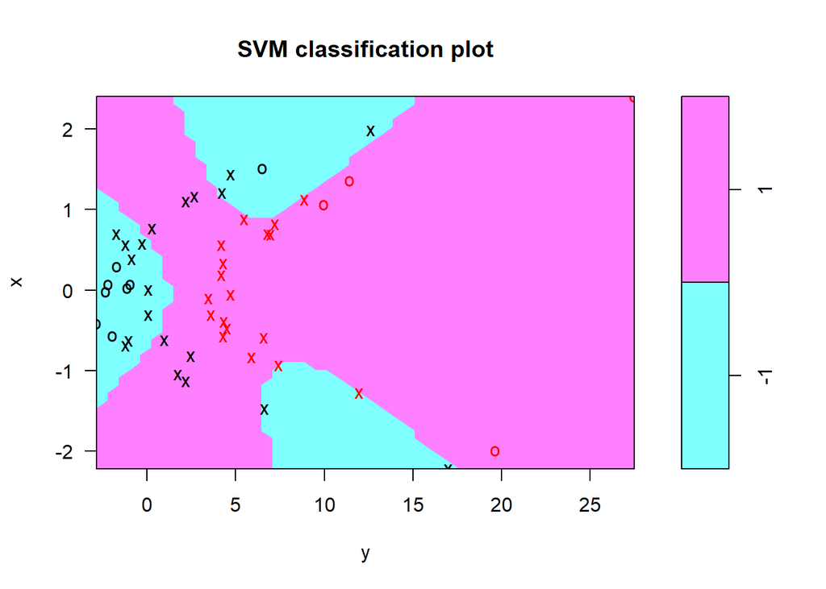

```r
poly <- svm(z ~ ., data = train, kernel = "polynomial", cost = 10)
plot(poly, train)
```

```r
table(predict(poly, train), train$z)
```

```
##
##      -1  1
##   -1 19  0
##   1   9 22
```

We can see from the table above, this method with a polynomial kernel of degree 3 has 9 errors.

SVM (radial kernel with gamma 1)

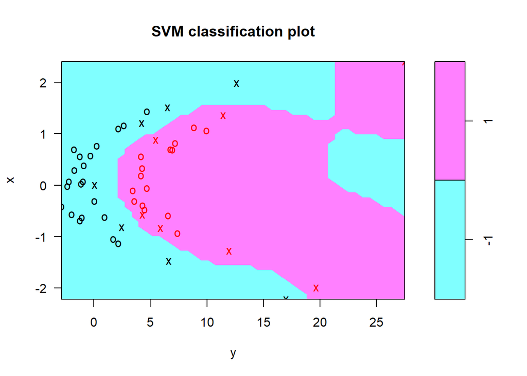

```r
radial <- svm(z ~ ., data = train, kernel = "radial", gamma = 1, cost = 10)
plot(radial, train)
```

```r
table(predict(radial, train), train$z)
```

```
##
##      -1  1
##   -1 28  0
##   1   0 22
```

We can see from the table above, this current method has 0 error.

Test model performance on the test data below.

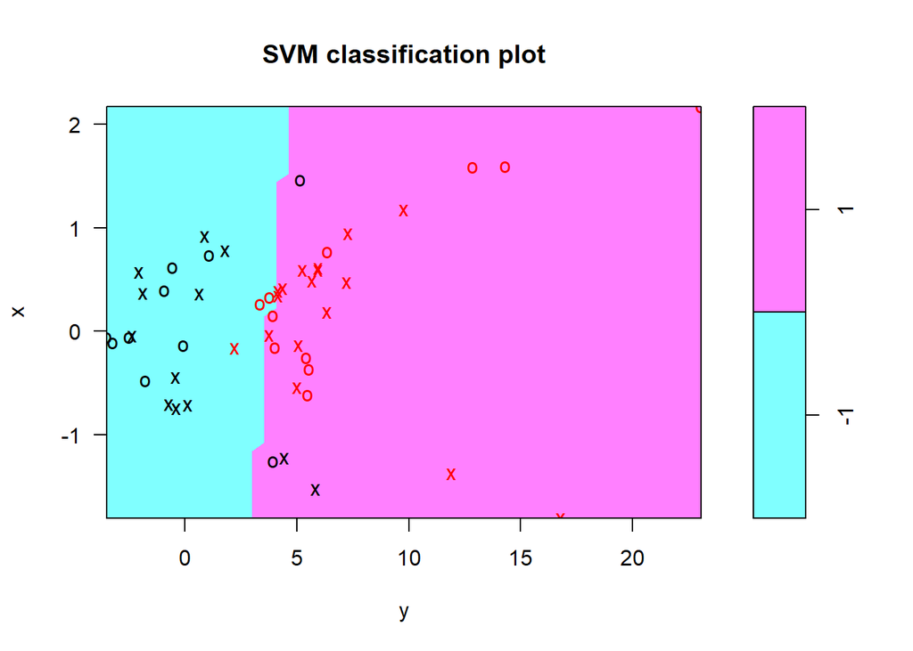

```r
plot(linear, test)
```

```r
table(predict(linear, test), test$z)
```

```
##
##      -1  1
##   -1 18  2
##   1   4 26
```

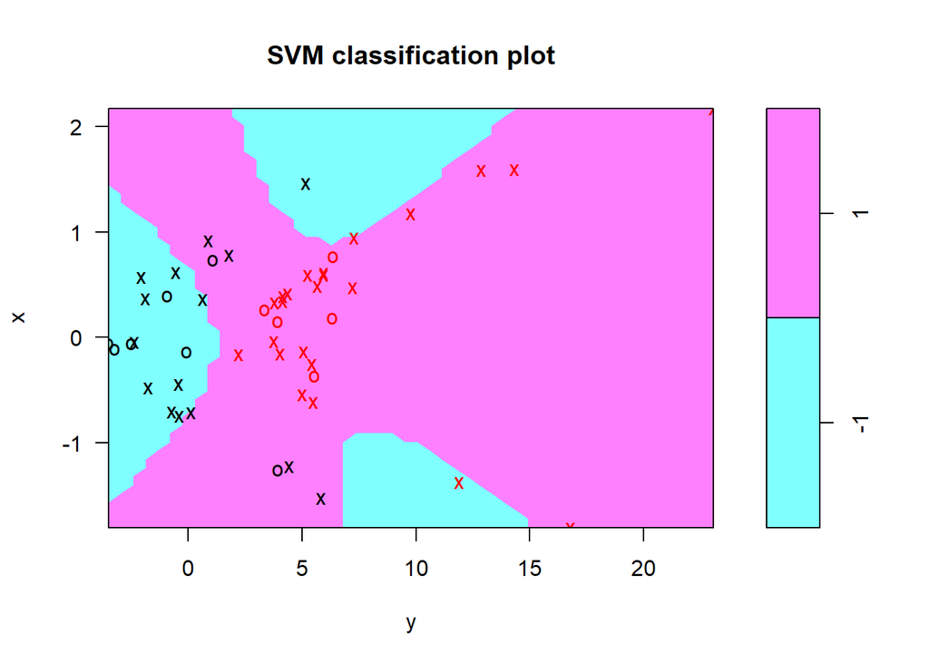

```r
plot(poly, test)
```

```r
table(predict(poly, test), test$z)
```

```
##
##      -1  1
##   -1 14  1
##   1   8 27
```

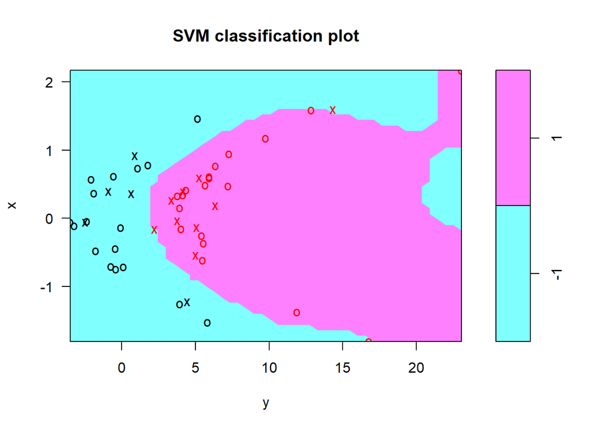

```r
plot(radial, test)
```

```r
table(predict(radial, test), test$z)
```

```
##
##      -1  1
##   -1 22  1
##   1   0 27
```

After applying models to the test data, we can see from the results above that the linear svm model has 6 errors; the polynomial svm model has 9 errors; the radial svm model has 1 error. Obviously, the svm model with a radial kernel is the best performer in our case.

# Section 10.7

# Q2

# a

Based on Algorithm 10.2, we have the following: I. We have the dissimilarity matrix provided in the problem.
$$\pmatrix{ &0.3 &0.4 &0.7 \cr 0.3 & &0.5 &0.8 \cr 0.4 &0.5 & & 0.45 \cr 0.7 &0.8 &0.45 & }$$
II. i = 4, let’s fuse obs 1 and 2 to generate a cluster (1,2) at height 0.3 because 0.3 is the minimum dissimilarity in the previous matrix.
$$\pmatrix{ &0.5 &0.8 \cr 0.5 & &0.45 \cr 0.8 &0.45 & }$$
III. i = 3, let’s fuse obs 3 and 4 to generate a cluster (3,4) at height 0.45 because 0.45 is the minimum dissimilarity in the previous matrix.
$$\pmatrix{ &0.8 \cr 0.8 & }$$
IV. i = 4, let’s fuse both clusters (1,2) and (3,4) to generate a cluster ((1,2),(3,4)) at height 0.8.

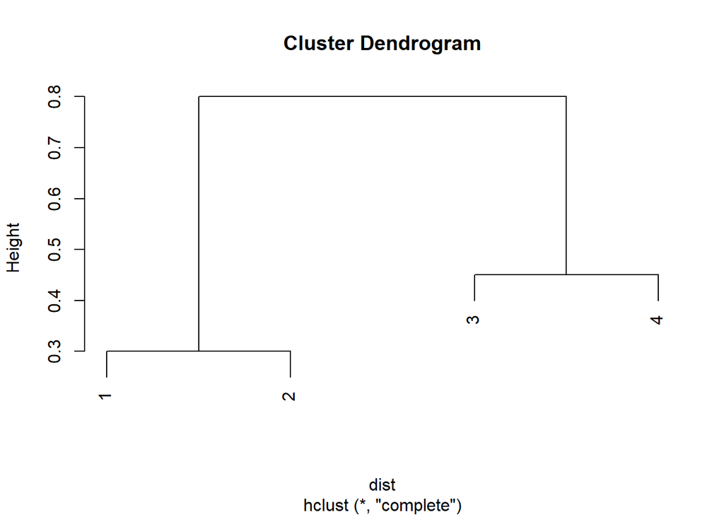

```r
dist <- as.dist(matrix(c(0, 0.3, 0.4, 0.7, 0.3, 0, 0.5, 0.8, 0.4, 0.5, 0.0, 0.45, 0.7, 0.8, 0.45, 0.0), nrow = 4))
plot(hclust(dist, method = "complete"))
```

# b

Based on Algorithm 10.2, we have the following: I. We have the dissimilarity matrix provided in the problem.
$$\pmatrix{ &0.3 &0.4 &0.7 \cr 0.3 & &0.5 &0.8 \cr 0.4 &0.5 & & 0.45 \cr 0.7 &0.8 &0.45 & }$$
II. i = 4, let’s fuse obs 1 and 2 to generate a cluster (1,2) at height 0.3 because 0.3 is the minimum dissimilarity in the previous matrix.
$$\pmatrix{ &0.4 &0.7 \cr 0.4 & &0.45 \cr 0.7 &0.45 & }$$
III. i = 3, let’s fuse obs 3 and (1,2) to generate a cluster (3,(1,2)) at height 0.4 because 0.4 is the minimum dissimilarity in the previous matrix.
$$\pmatrix{ &0.45 \cr 0.45 & }$$
IV. i = 4, let’s fuse clusters ((1,2),3) and obs 4 to generate a cluster (((1,2),3),4) at height 0.45.

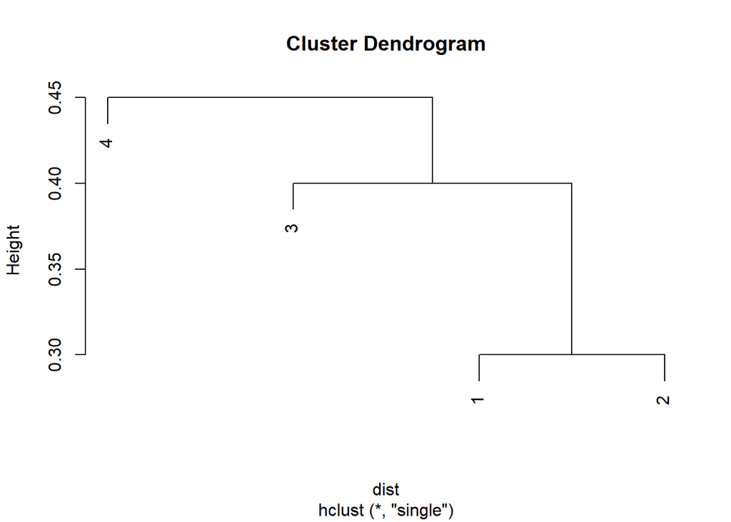

```r
plot(hclust(dist, method = "single"))
```

# c

For part(a), (1,2) and (3,4).

# d

For part(b), ((1,2),3) and (4).

# Q11

# a

```r
genedata <- read.csv("Ch10Ex11.csv", header = F)
```

# b

I will try three different types of linkage below.

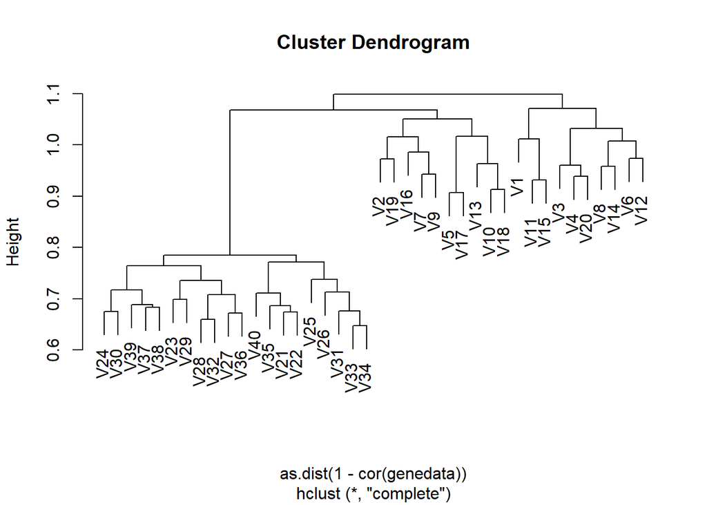

```r
complete <- hclust(as.dist(1-cor(genedata)), method = "complete")
plot(complete)
```

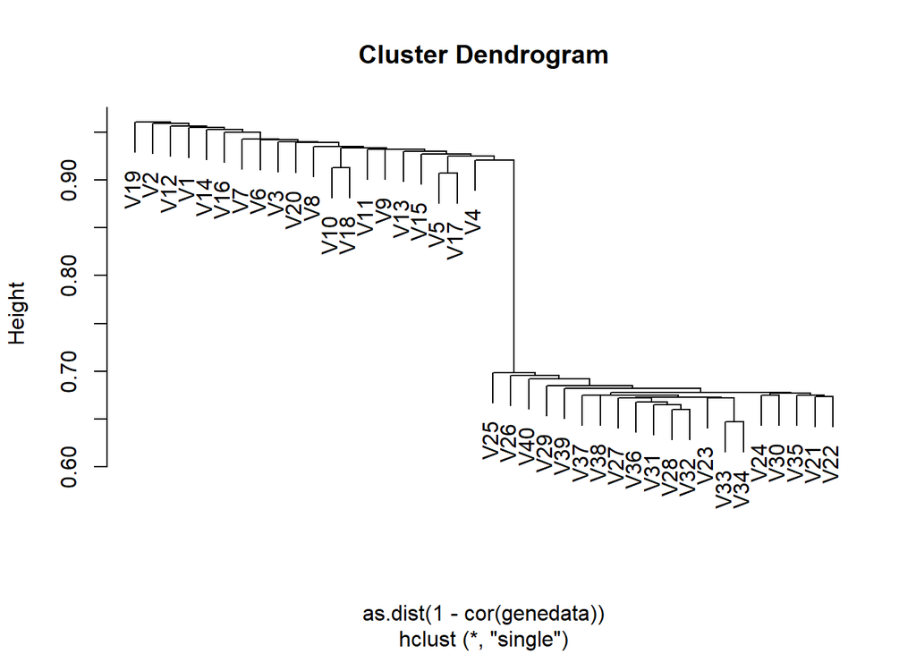

```r
single <- hclust(as.dist(1-cor(genedata)), method = "single")
plot(single)
```

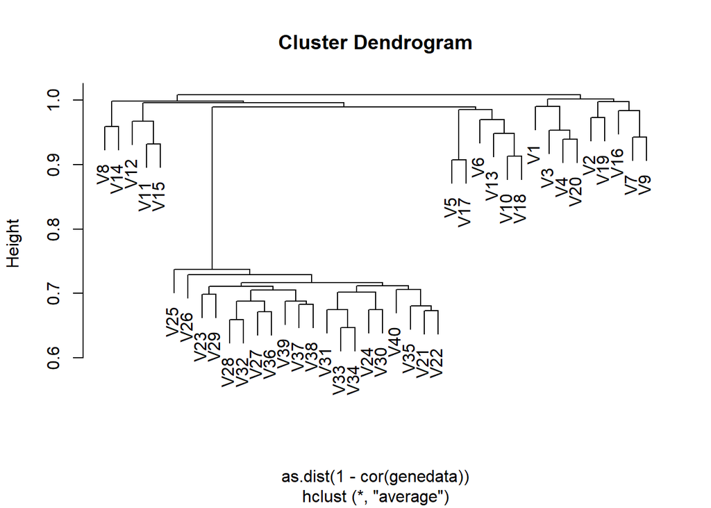

```r
average <- hclust(as.dist(1-cor(genedata)), method = "average")
plot(average)
```

We can see from the graphs, different linkage methods yield very different results. We have two clusters for the first two methods and three clusters for the last one.

# c

We can use PCA method to answer this question. Check the absolute values of the total loadings for every single gene because they represent the weight of every single gene.

```r
output <- prcomp(t(genedata))
head(output$rotation)
```

```
##               PC1          PC2          PC3          PC4          PC5
## [1,] -0.002434664 -0.030745799  0.009359932  0.009699551 -0.012847866
## [2,] -0.002016598 -0.025927592  0.050300983 -0.026082885  0.003488293
## [3,]  0.011233842 -0.003937802  0.014564920  0.054373032 -0.020411836
## [4,]  0.013912855  0.025625408  0.033998676 -0.011530298 -0.009364524
## [5,]  0.007293322  0.013590353 -0.008229702 -0.001343010  0.030002978
## [6,]  0.017928318 -0.026302699 -0.020728401 -0.024069152 -0.018619253
##               PC6          PC7          PC8          PC9         PC10
## [1,]  0.023439995  0.010152261 -0.024602570 -0.021925557 -0.035003076
## [2,]  0.001605492 -0.037364376 -0.017332292  0.011319311  0.007802611
## [3,]  0.025337127  0.070772412  0.047340581 -0.013963868  0.023624407
## [4,]  0.029529539  0.002885764 -0.093667774 -0.008391226 -0.019226470
## [5,] -0.017042934  0.003555111 -0.053227214 -0.010479774  0.008446406
## [6,] -0.049103273 -0.040473304 -0.005455454 -0.003882692  0.028472950
##              PC11         PC12         PC13         PC14         PC15
```

[output cut: 41 more lines]

```r
loadings <- apply(output$rotation, 1, sum)
i <- order(abs(loadings), decreasing = TRUE)
i[1:15] #output the top 10 results
```

```
##  [1] 865  68 911 428 624  11 524 803 980 822 529 765 801 771 570
```

The above are the 15 most different genes across the two groups.